# 关于西安市Java开发工程师工资的报告

2014303507-陈佳

2017年10月19日

## 报告主题

本报告为了解决以下几点问题：

1. 西安市Java开发工程师工资与学历、工作经验的关系
2. 给定一个求职者的学历、工作经验以及期望的公司类型，预期其工资水平

## 数据来源

本报告对`前程无忧`网站进行爬虫，主要采集以下几方面的数据,爬虫代码见作业中`代码`部分。

- 公司类型
- 工作经验要求
- 学历要求
- 最高工资及最低工资
- 职位名称
- 公司名称

## 分析思路

在**依然很拉风**的[数据可视化基本套路总结](http://www.jianshu.com/p/1f9db668a8c2)中引用以下观点：

> 数据可视化本身是表层的东西，可是一款优秀的数据可视化一定要有深刻的内涵。从技术的角度来说，要有大数据整理、数据分析和数据挖掘的智能因子在里面；从背景的角度来说，可视化作品就如同文艺作品一样要源于实际，高于实际，假大空、纯粹只为了炫技的可视化并没有什么意义。

分析思路主要包含以下几步。

### 分析思路1

- 首先，对于爬虫所得某公司某职位的最高工资以及最低工资取平均，新建一列salary，将所得数据记入该列，salary即为该公司该职位的平均工资

### 分析思路2

- 其次，分析工资与学历、工作经验以及公司类型的关系，分析某一因素与工资的关系时，控制其他因素相同，观察该因素与工资的关系，正比、反比或者无关

### 分析思路3

- 最后，给定一个求职者的学历、工作经验以及期望的公司类型，预期其工资水平，可使用朴素贝叶斯模型，因为自变量学历、工作经验以及公司类型都是相互独立的变量，因而所得到的结果较为准确

## 计算过程

以下是数据分析和数据挖掘过程

```r
# 导入所需要的包
library(ggplot2)
library(dplyr)
library(stringr)
library(DT)
```

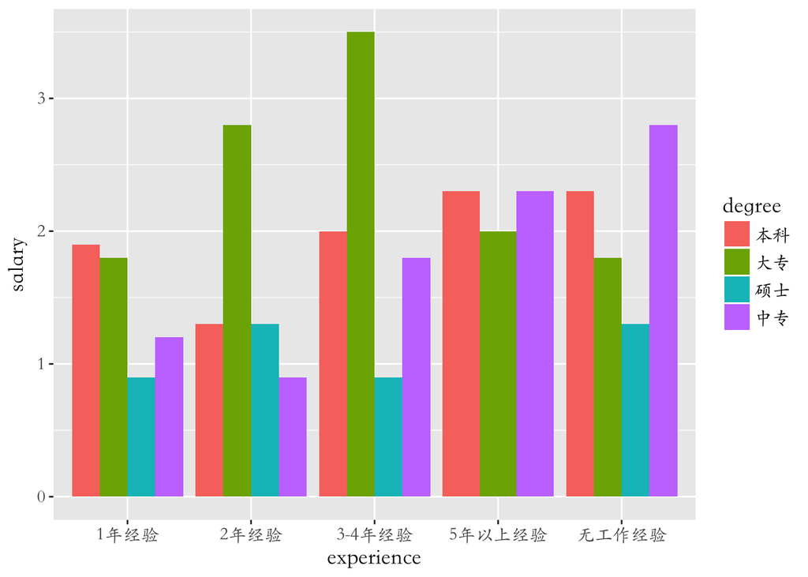

```r
# 图片展示的代码
jobs<-read.csv("/Users/orange/Desktop/jobs-pic.csv",fileEncoding = "gbk",header=T)
ggplot(data=jobs,aes(experience,salary,fill=degree))+
  geom_bar(stat="identity",position="dodge")+theme(text=element_text(family="STKaiti",size=14))
```

```r
# 交互式表格，展示数据用，数据量太大不要全部展示，否则内存会爆！
jobs<-read.csv("/Users/orange/Desktop/jobs-origin.csv",fileEncoding = "gbk",header=T)

DT::datatable(jobs %>% head(200))
```

|  | title | company | degree | experience | max_salary..month. | min_salary..month. | place | title.1 | CompanyType |
| --- | --- | --- | --- | --- | --- | --- | --- | --- | --- |
| 1 | Java/php开发工程师 | 金月汇大健康产业管理有限公司 | 中专 | 无工作经验 | 0.6 | 0.45 | 西安 | Java/php开发工程师 | 民营 |
| 2 | java开发工程师 | 北京中软国际信息技术有限公司 | 本科 | 无工作经验 | 1 | 0.8 | 西安-高新技术产业开发区 | java开发工程师 | 合资 |
| 3 | Java高级开发工程师 | 中创三优（北京）科技有限公司 | 本科 | 5-7年经验 | 1.3 | 0.8 | 西安-高新技术产业开发区 | Java高级开发工程师 | 合资 |
| 4 | 中级JAVA工程师 | 西安银博科技有限责任公司 | 本科 | 3-4年经验 | 1.3 | 0.8 | 西安 | 中级JAVA工程师 | 国企 |
| 5 | JAVA PL工程师职位 | 西安安谷运合软件技术有限公司 | 本科 | 3-4年经验 | 1.4 | 0.7 | 西安 | JAVA PL工程师职位 | 民营 |
| 6 | Java研发工程师 | 深圳安道云科股份有限公司 | 本科 | 1年经验 | 0.8 | 0.6 | 西安-雁塔区 | Java研发工程师(T3. 工程师) (职位编号：T3) | 民营 |
| 7 | Java开发工程师 | 深圳震有科技股份有限公司 | 本科 | 2年经验 | 1.2 | 0.6 | 西安-高新技术产业开发区 | Java开发工程师 | 民营 |
| 8 | 高级Java开发工程师 | 西安冠群信息技术有限公司 | 大专 | 5-7年经验 | 1.5 | 1 | 西安-雁塔区 | 高级Java开发工程师 | 上市 |
| 9 | JAVA开发工程师 | 西安榴莲网络科技有限公司 | 本科 | 3-4年经验 | 1.5 | 1 | 西安-高新技术产业开发区 | JAVA开发工程师 | 民营 |
| 10 | java 软件开发工程师 | 西安同凯电子科技有限责任公司 | 本科 | 3-4年经验 | 0.7 | 0.4 | 西安-高新技术产业开发区 | java 软件开发工程师 | 民营 |

[output cut: 190 more lines]

## 朴素贝叶斯模型

```r
#朴素贝叶斯模型预测代码,对数据进行处理，用特定数字代替文字，去除多余信息
library(e1071)
library(ISLR)
jobs<-read.csv("/Users/orange/Desktop/jobs-model.csv")
train <- sample(1:nrow(jobs),nrow(jobs)*0.8)
nb <- naiveBayes(jobs[,-4],jobs[,4],subset=train)
mat <- as.matrix(table(predict(nb,jobs[-train,]),jobs[-train,4]))
sum(diag(mat)/sum(mat))
```

```
## [1] 0.6642857
```